# Highcharts

2022-07-26

## INTRO

[figure not shown]

**How to visualize**

## I. 들어가는 글

- 데이터는 중요하다.

- 그러나, 데이터를 이해하여 그것을 가공해 활용할 수 없다면  
  데이터는 무의미하다.
- 그렇기에 데이터 시각화는 데이터를 적시에 적절한 사람에게  
  제공하는 가장 효과적인 수단이다.

## I. highchart의 특징: ggplot2 그래프

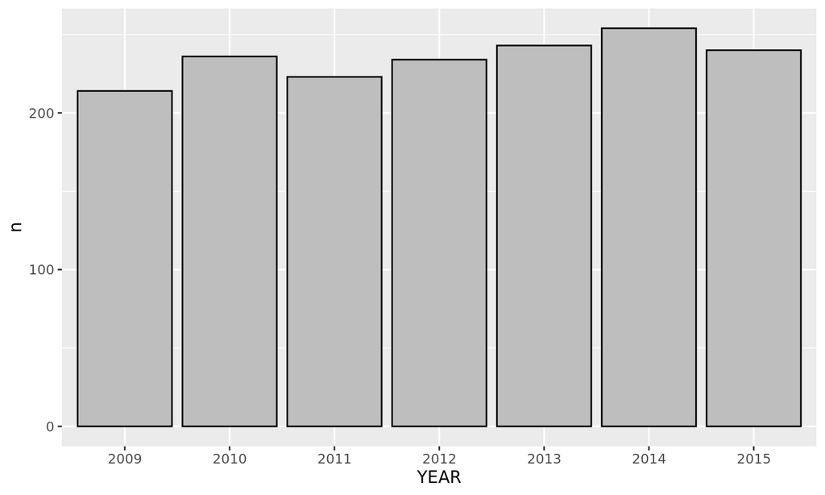

## I. highchart의 특징: highchart 그래프

[interactive chart not shown]

## highchart package

**highchart**

## II. 사용할 데이터

- **예시용**: survey_results_public.csv  
- **실습용**: example_g1e.csv + 내재된 데이터(mtcars, iris 등)  
dt<-fread(“https://raw.githubusercontent.com/jinseob2kim/lecture-snuhlab/master/data/example_g1e.csv”)

## II. highchart 기본 구조 (1)

**highchart( ) 와 hchart( ) 의 차이점?**  
- highchart( ) ≒ ggplot( )  
- hchart( ) ≒ qplot( )

## II. highchart 기본구조 (2)

**highchart( )란 ?**  
**highchart( )의 기본구조**

hchart( data, type of chart, hcaes(aesthetics), … )

- data: 차트를 만들 데이터를 적는 곳
- type of chart: 어떤 종류의 차트를 그릴 지 구체화
- hcaes(aes): 그림의 X축, Y축을 정하는 곳
- 기타 : hc_add_series, hc_add_theme, hc_title 등

## II. hchart

**1. 막대그래프 시리즈**  
- type of chart 에 **column, bar, line** 등을 기입  
- 가장 기본적인 그래프 + 활용하기 가장 용이함

## II. hchart - Column

```r
survey18 %>%
  count(HopeFiveYears) %>%
  hchart('column', hcaes(x="HopeFiveYears", y="n"))
```

[interactive chart not shown]

## II. hchart - Bar

```r
survey18 %>%
  count(HopeFiveYears) %>%
  hchart('bar', hcaes(x="HopeFiveYears", y="n"))
```

[interactive chart not shown]

## II. hchart - Bar

```r
survey18 %>%
  count(HopeFiveYears, Employment) %>%
  hchart('bar', hcaes(x="HopeFiveYears", y="n", group="Employment"))
```

[interactive chart not shown]

## II. hchart_add 기본

- **hc_title**

(**text** = ‘title’ , **align** = ‘center’,

**style** = list(fontWeight=’bold’, fontSize = ‘Npx’))

- **hc_credits** (**enabled** = T, **text** = ‘caption’)
- **hc_colors** (‘color’)
- **hc_add_theme**(hc_theme( ))

## II. hchart_add 심화

- **hc_add_series**

- **hc_tooltip**
- **hc_xAxis** , **hc_yAxis**
- **hc_plotOptions**

## II. hc_tooltip

[interactive chart not shown]

## II. hchart_add 심화

- **hc_add_series**

- **hc_tooltip**
- **hc_xAxis** , **hc_yAxis**
- **hc_plotOptions**

## II. hc_xAxis & hc_yAxis

[interactive chart not shown]

## II. hchart_add 심화

- **hc_add_series**

- **hc_tooltip**
- **hc_xAxis** , **hc_yAxis**
- **hc_plotOptions**

## II. hc_plotOtions

[interactive chart not shown]

## II. EXAMPLE

```r
survey18 %>%
  count(HopeFiveYears) %>%
  hchart('column', hcaes(x="HopeFiveYears", y="n")) %>%
  hc_title(text="Hoping what to do in 5 years", align='center') %>%
  hc_colors("red") %>%
  hc_add_theme(hc_theme_538()) %>%
  hc_credits(enabled=T, text="survey_public_18")
```

## II. EXAMPLE

[interactive chart not shown]

## II. hchart - 3D

```r
highchart() %>%
  hc_chart(type="column",
           options3d=list(enabled=T, beta=15, alpha=15)) %>%
  hc_xAxis(categories = Gender$Gender) %>%
  hc_add_series(data=Gender$n, name="Gender") %>%
  hc_colors("blue")
```

[interactive chart not shown]

## II. hchart - Line

```r
data(economics_long, package="ggplot2")
economics_long2<-filter(economics_long, variable %in% c("pop", "uempmed", "unemploy"))
hchart(economics_long2, "line", hcaes(x=date, y=value01, group=variable))
```

[interactive chart not shown]

## II. hchart - Area Charts

```r
survey18 %>%
  count(HopeFiveYears) %>%
  hchart('area', hcaes(x="HopeFiveYears", y="n"))
```

[interactive chart not shown]

## II. hchart - Area Charts

```r
survey18 %>%
  count(HopeFiveYears,Employment) %>%
  hchart('area', hcaes(x="HopeFiveYears", y="n", group="Employment"))
```

[interactive chart not shown]

## II. hchart - Area Charts

```r
survey18 %>%
  count(HopeFiveYears) %>%
  hchart('areaspline', hcaes(x="HopeFiveYears", y="n"))
```

[interactive chart not shown]

## II. hchart - Scatter Plot (1)

```r
dt1 %>%
  hchart(type='scatter', hcaes(x="WGHT", y="HGHT"))
```

[interactive chart not shown]

## II. hchart - Scatter Plot (2)

```r
install.packages('palmerpenguins')
library(palmerpenguins)
```

## II. hchart - Scatter Plot (2)

[interactive chart not shown]

## II. hchart - Treemap

```r
survey18 %>%
  filter(!is.na(Age)) %>%
  count(Age) %>%
  hchart('treemap', hcaes(x='Age', value='n', color='n'))%>%
  hc_colorAxis(minColor='pink', maxColor='lightblue')
```

[interactive chart not shown]

## II. hchart - Pie Charts

```r
survey18 %>%
  count(HopeFiveYears) %>%
  hchart(type = 'pie', hcaes(HopeFiveYears, n))
```

[interactive chart not shown]

## III. 다양한 그래프 형태 (1)

[interactive chart not shown]

## III. 다양한 그래프 형태 (2)

[interactive chart not shown]

## III. 다양한 그래프 형태 (3)

[interactive chart not shown]

## IV. 실습 (1)

[interactive chart not shown]

## IV. 실습 (1)

- **example_g1e.csv** 파일을 불러옴

- **select** 함수를 이용해서 **EXMD_BZ_YYY, HGHT, WGHT, BMI**

변수만 추출

- 데이터 안에 각 연도별 데이터가 몇개씩 존재하는지

확인하는 그래프 그리기. (**count** 함수 이용)

- **highchart** 그리기. 차트 형태는 **column**

테마는 **hc_theme_flatdark** 이용.

## IV. 실습 (2)

[interactive chart not shown]

## IV. 실습 (2)

- 위의 **select**를 이용해 추출한 자료 이용

- **Weight**와 **Height**의 상관관계 파악하기
- 차트 형태는 **scatter**
- 제목: **Correlation between Weight and Height**
- 부제: **By Year**
- 제목과, 부제 둘 다 **가운데 정렬**
- 캡션으로 **By 09-15 공단 데이터** 넣기
- 테마는 **hc_theme_538** 이용

## V. Reference

**1. 참고할 만한 사이트 (1)**

- https://www.highcharts.com/blog/data-science/highcharts-for-r-users/?fbclid=IwAR1hDXWYPmucAuTjMRUNSm5iM_y4Pa6OF1eeOW8ohg5WwDmDpb29flFPVIc **(메인 사이트)**
- https://youngjunna.github.io/r/2019/07/15/highcharter-theme.html **(theme 관련)**
- Function reference • highcharter (jkunst.com) **(hcart 함수 인자 요소 관련)**
- Charts with highcharts • highcharter (jkunst.com) **(type of chart 관련)**

## V. Reference

**1. 참고할 만한 사이트 (2)**

- R로 그래프 그릴 때 깔끔하게 팔레트 선택하기(feat. colorspace) : kini’n creations (tistory.com) **(color 관련)**
- https://cran.r-project.org/web/packages/highcharter/highcharter.pdf **(hc_chart Index 및 사용방법)**

## V. Reference

**2. 강의록 작성 참고자료**

- https://www.kaggle.com/code/nulldata/beginners-guide-to-highchart-visual-in-r/report
- https://www.datacamp.com/tutorial/data-visualization-highcharter-r
- https://towardsdatascience.com/exploring-highcharts-in-r-f754143efda7
- https://jkunst.com/highcharter/index.html